# Analysis of Loan Data from Prosper by James R. Small

> Borrower APR faceted by Employment Status - while no major differences are apparent, the Not available group has the highest APRs, and the unemployed have a pronounced spike of APRs at the higher end (around .35):

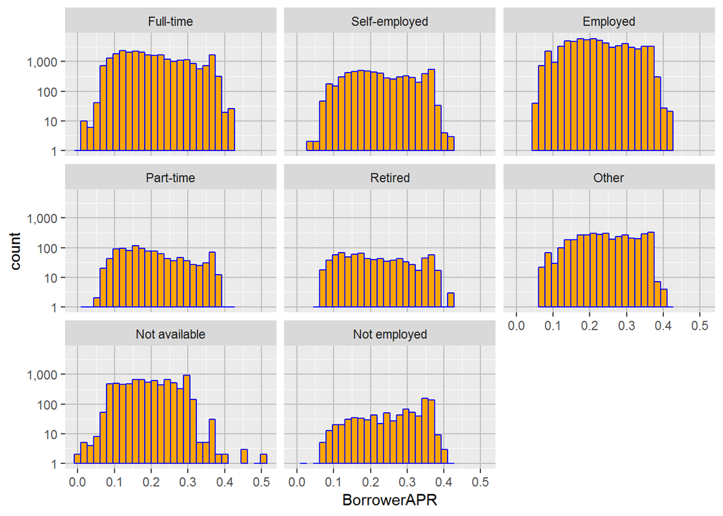

> Borrower APR faceted by the Loan Status - no major differences jump out here. One observation is that loans with an APR greater than .4 appear to have a higher risk of default:

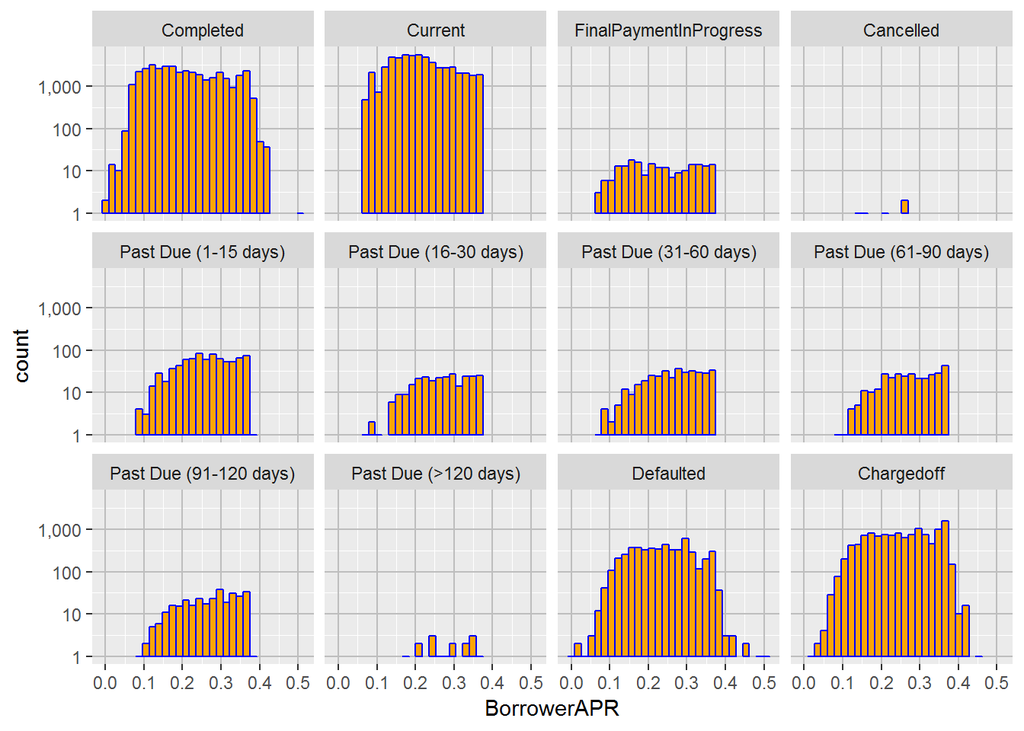

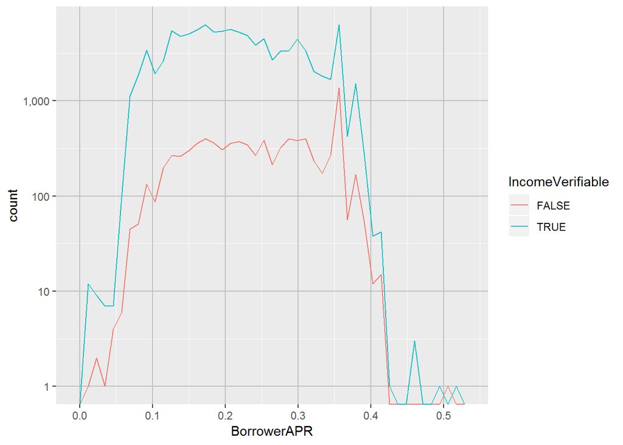

> Borrower APR contrasting by home ownership - here too there appears to be little difference. There’s a small number of low APR loans at the beginning of the curve where non-homeowners have a lower APR - not what we’d expect. However, at the high end there are several high APR loans and these are only to non-homeowners - what we would expect:

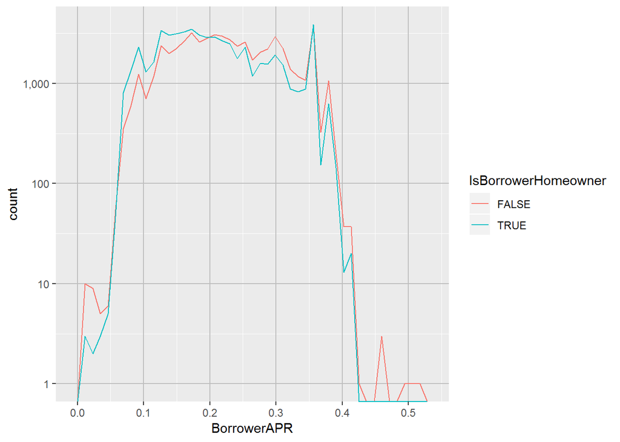

> Borrower APR faceted by employment status - the only group that stands out here is the NA one. This is where nothing was entered for employment status. In this group, we have the highest APR loans - going all the way up to over .5:

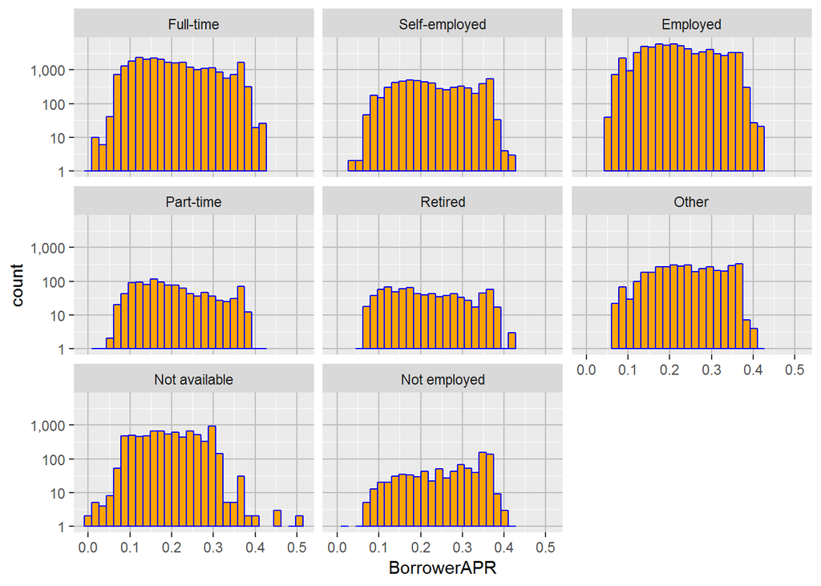

> Borrower APR faceted by credit grade from Prosper (Pre-2009) - Here we see a clear correlation between Prosper’s rating and the APR. As the rating decreases, the average APR increases. This is illustrated by a black line showing the mean for each group. The exceptions being that the HR category is about the same as E and the NC category average is only a little higher than D with a different distribution:

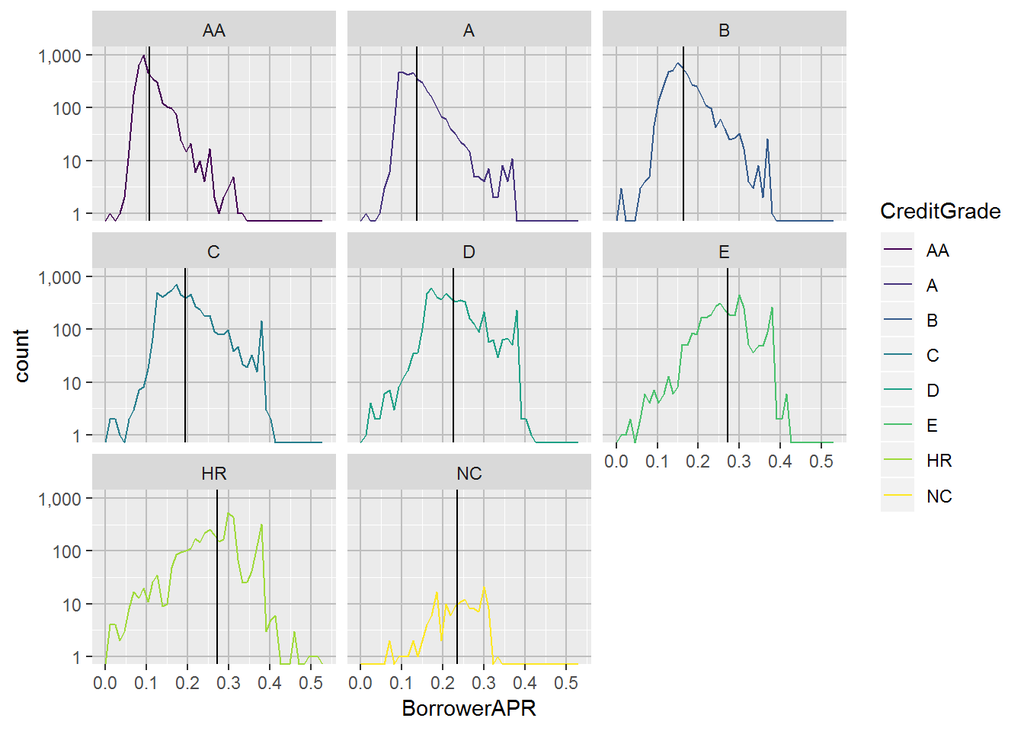

```
## CreditGrade: AA
##    Min. 1st Qu.  Median    Mean 3rd Qu.    Max.    NA's
## 0.01650 0.08634 0.09688 0.10619 0.11746 0.33172      14
## --------------------------------------------------------
## CreditGrade: A
##    Min. 1st Qu.  Median    Mean 3rd Qu.    Max.    NA's
## 0.01315 0.10629 0.12552 0.13570 0.15326 0.36623       1
## --------------------------------------------------------
## CreditGrade: B
##    Min. 1st Qu.  Median    Mean 3rd Qu.    Max.    NA's
## 0.01325 0.13705 0.15602 0.16434 0.18424 0.37633       2
## --------------------------------------------------------
## CreditGrade: C
##    Min. 1st Qu.  Median    Mean 3rd Qu.    Max.    NA's
## 0.00653 0.15211 0.18044 0.19346 0.21933 0.40243       3
## --------------------------------------------------------
## CreditGrade: D
##    Min. 1st Qu.  Median    Mean 3rd Qu.    Max.    NA's
## 0.00653 0.17722 0.21397 0.22553 0.25517 0.41355       1
## --------------------------------------------------------
## CreditGrade: E
##    Min. 1st Qu.  Median    Mean 3rd Qu.    Max.    NA's
## 0.01657 0.23497 0.26914 0.27071 0.30349 0.41355       1
## --------------------------------------------------------
## CreditGrade: HR
##    Min. 1st Qu.  Median    Mean 3rd Qu.    Max.    NA's
## 0.00864 0.23215 0.28179 0.27126 0.30564 0.51229       2
## --------------------------------------------------------
## CreditGrade: NC
##    Min. 1st Qu.  Median    Mean 3rd Qu.    Max.    NA's
## 0.06698 0.18824 0.24126 0.23501 0.28771 0.33745       1
```

> Borrower APR faceted by his rating from Prosper (Post-July, 2009) - Here we see a revised Prosper rating system with ever clearer groupings. As the borrower rating decreases, the average APR increases without exception:

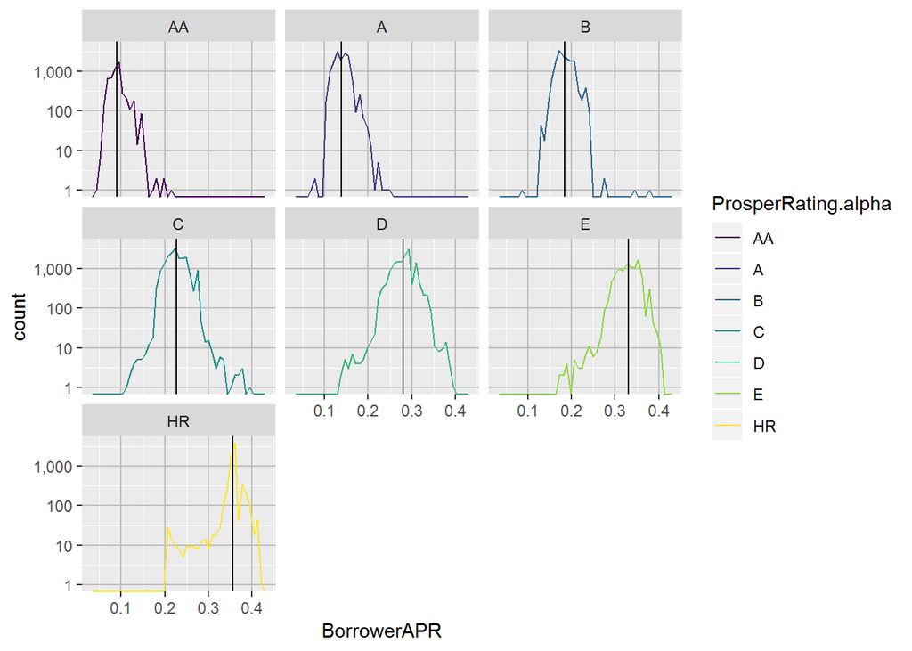

```
## ProsperRating.alpha: AA
##    Min. 1st Qu.  Median    Mean 3rd Qu.    Max.
## 0.04583 0.07922 0.09000 0.09004 0.09736 0.21368
## --------------------------------------------------------
## ProsperRating.alpha: A
##    Min. 1st Qu.  Median    Mean 3rd Qu.    Max.
## 0.07045 0.12614 0.13799 0.13891 0.14985 0.24807
## --------------------------------------------------------
## ProsperRating.alpha: B
##    Min. 1st Qu.  Median    Mean 3rd Qu.    Max.
## 0.08999 0.17151 0.18173 0.18417 0.19645 0.37453
## --------------------------------------------------------
## ProsperRating.alpha: C
##    Min. 1st Qu.  Median    Mean 3rd Qu.    Max.
##  0.1115  0.2102  0.2236  0.2263  0.2425  0.3915
## --------------------------------------------------------
## ProsperRating.alpha: D
##    Min. 1st Qu.  Median    Mean 3rd Qu.    Max.
##  0.1406  0.2653  0.2853  0.2808  0.2951  0.3915
## --------------------------------------------------------
## ProsperRating.alpha: E
##    Min. 1st Qu.  Median    Mean 3rd Qu.    Max.
##  0.1743  0.3116  0.3322  0.3307  0.3513  0.4068
## --------------------------------------------------------
## ProsperRating.alpha: HR
##    Min. 1st Qu.  Median    Mean 3rd Qu.    Max.
##  0.2026  0.3536  0.3580  0.3561  0.3580  0.4239
```

> Borrower delinquencies for last 7 years faceted by loan status - no useful pattern observed:

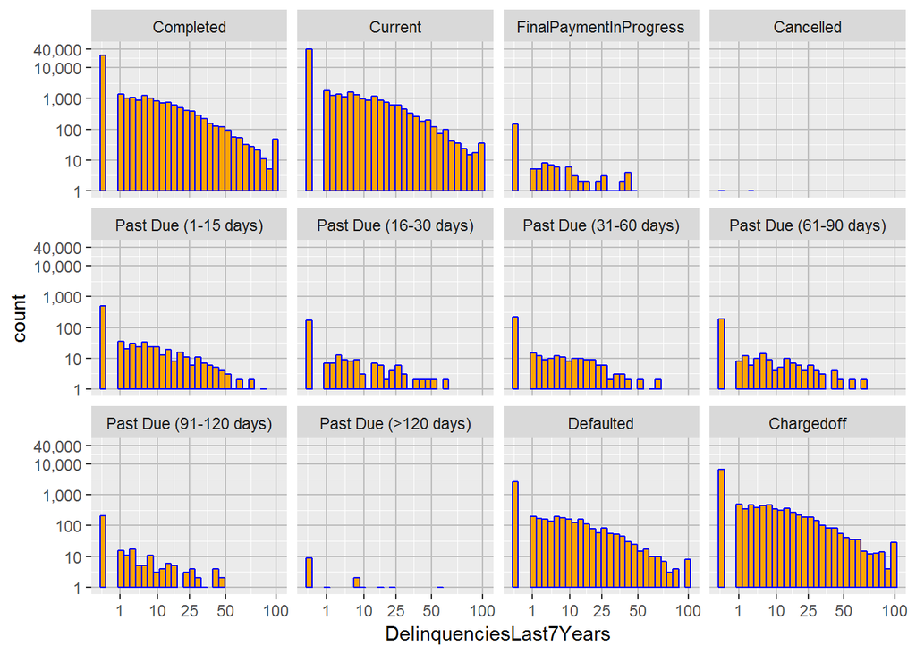

> Borrower amount delinquent faceted by loan status - no useful pattern observed:

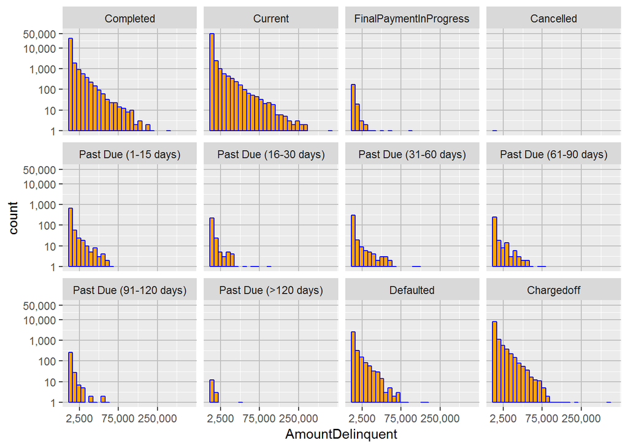

> Borrower credit score faceted by credit grade from Prosper (Pre-2009) - as we’d expect, there’s a strong correlation between the borrower’s credit grade and the Prosper credit grade:

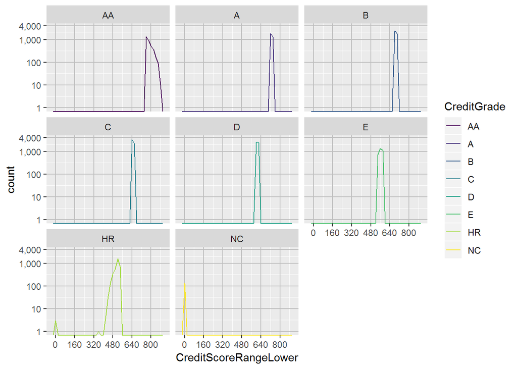

> Borrower credit score faceted by Prosper ranking from Prosper (Post-July, 2009) - in contrast to Propser’s credit grade score, Prosper’s ranking is more nuanced. While there’s a correlation betwen the borrower’s credit score and the ranking (highlighted by the black line showing the mean score), the groups are much more spread out than with the credit grade. Clearly there are other factors baked into the ranking than just the credit score:

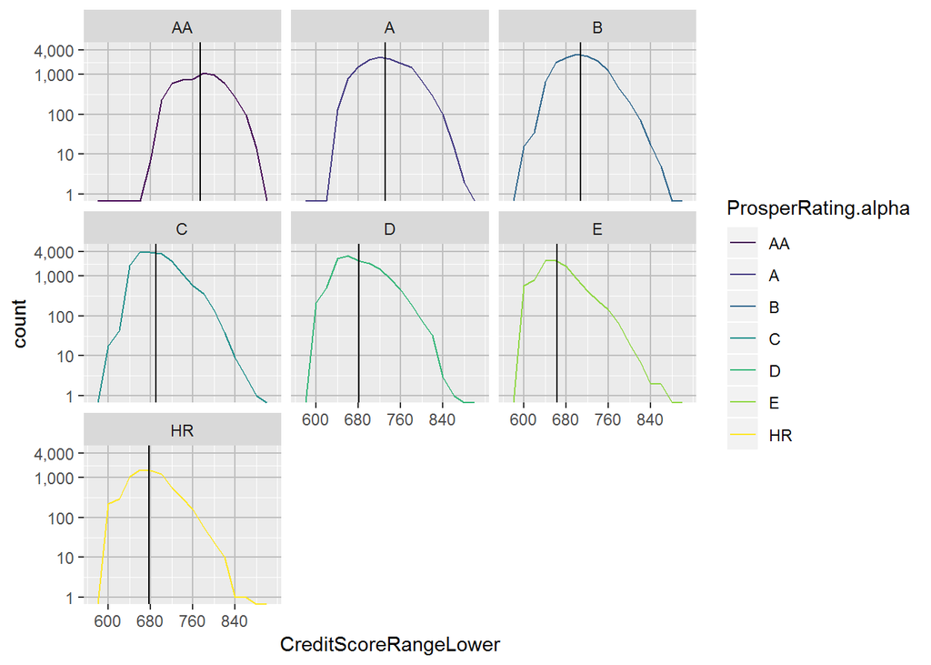

```
## ProsperRating.alpha: AA
##    Min. 1st Qu.  Median    Mean 3rd Qu.    Max.
##   680.0   740.0   780.0   774.3   800.0   880.0
## --------------------------------------------------------
## ProsperRating.alpha: A
##    Min. 1st Qu.  Median    Mean 3rd Qu.    Max.
##   640.0   700.0   720.0   730.2   760.0   880.0
## --------------------------------------------------------
## ProsperRating.alpha: B
##    Min. 1st Qu.  Median    Mean 3rd Qu.    Max.
##     600     680     700     707     740     860
## --------------------------------------------------------
## ProsperRating.alpha: C
##    Min. 1st Qu.  Median    Mean 3rd Qu.    Max.
##     600     660     680     690     720     880
## --------------------------------------------------------
## ProsperRating.alpha: D
##    Min. 1st Qu.  Median    Mean 3rd Qu.    Max.
##   600.0   660.0   680.0   680.4   700.0   860.0
## --------------------------------------------------------
## ProsperRating.alpha: E
##    Min. 1st Qu.  Median    Mean 3rd Qu.    Max.
##   600.0   640.0   660.0   662.6   680.0   860.0
## --------------------------------------------------------
## ProsperRating.alpha: HR
##    Min. 1st Qu.  Median    Mean 3rd Qu.    Max.
##   600.0   660.0   680.0   677.1   700.0   860.0
```

# Bivariate Analysis

### Investigating Correlations

> For the selected features, all significant correlations (|Pearson’s r| > .3) were investigated. The most popular term appears to be 36 months. Loosely speaking, larger loan amounts tend to have lower APRs. Not suprisingly, we see that borrowers with higher credit scores tend to get better (lower) APRs. Furthermore, it appears that the larger loans are only made available to borrowers with a better credit score. There’s a strong relationship between the loan amount and the monthly repayment amount - also not very surprising. Finally, we see that there’s a relationship between recommendations and investment from friends. Perhaps the borrowers friends both recommend and invest in them?

### Additional Exploration

> In addition to exploring correlated features, several other aspects were examined to look for what influences the APR charged. Many of the examined features revealed little to no relationship to the APR. The Prosper ratings unsurprisingly showed correlation to the APR. Examing these same Prosper ratings versus the borrower credit score was less clear cut. The older credit grade ranking showed a strong correlation to borrower’s credit score. However, the newer ranking system appears to include other factors with credit score only being only one of many.

# Multivariate Plots Section

> Borrower credit score vs. APR faceted by Prosper rating colored by term - here we see as the rating decreases, in addition to the APR going up, the term of the loan also decreases:

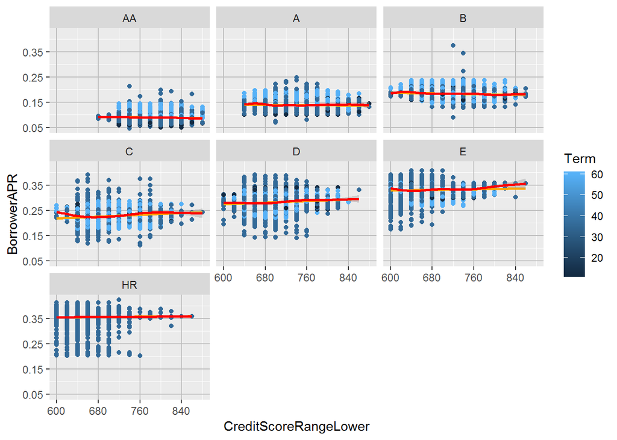

> Borrower credit score vs. APR faceted by Prosper rating colored by loan amount - as with the above plot, as the rating decreases the APR goes up and the amount of the loan also decreases:

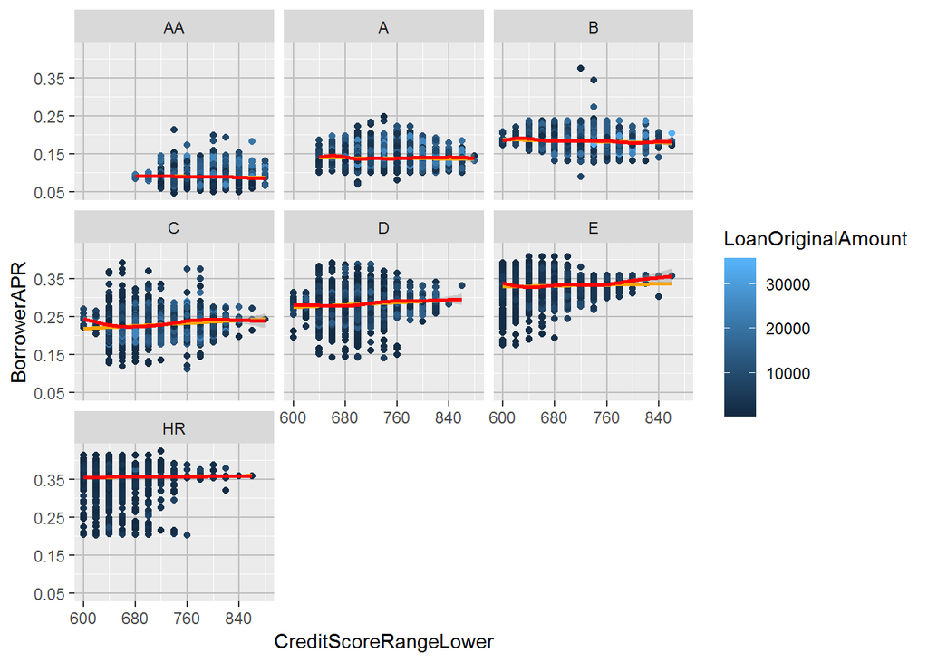

> Borrower credit score vs. APR faceted by Prosper rating colored by employment status. The dominant employment groups are employed and full time. While a little subtle, as the rating worsens, we can see the plots get more colorful. This is a result of including more of the groups which appear to have a higher incidence of problems:

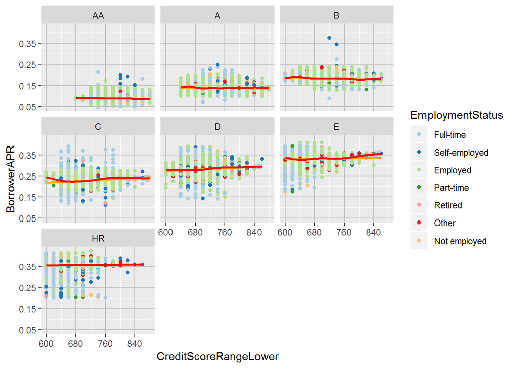

> Borrower stated monthly income vs. APR faceted by Prosper rating colored by if income is verifiable - recalling that the vast majority of borrowers stated their income is verifiable, the unverifiable ones appear to be mostly randomly distributed. The one exception is borrowers with no income appear to virtually all have this designation. In addition, while it’s not readily apparent in these plots, there is some correlation between income and rating - see the summary statistics following the plot. In addition, we see that while the first three rating groups are similar, as we cross into group C the income dispersion increases:

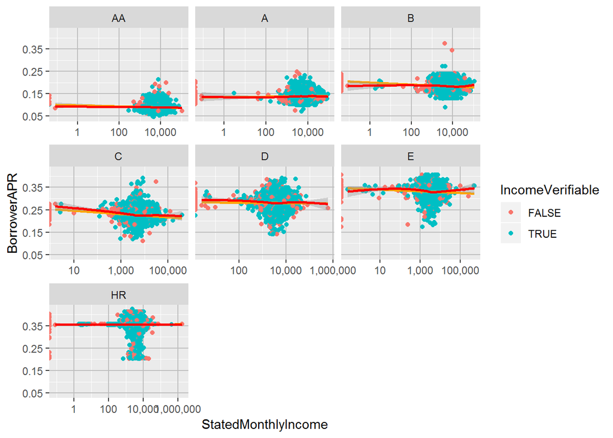

```
## ProsperRating.alpha: AA
##    Min. 1st Qu.  Median    Mean 3rd Qu.    Max.
##       0    4833    6667    7660    9167  108333
## --------------------------------------------------------
## ProsperRating.alpha: A
##    Min. 1st Qu.  Median    Mean 3rd Qu.    Max.
##       0    4167    5833    6744    8167   91667
## --------------------------------------------------------
## ProsperRating.alpha: B
##    Min. 1st Qu.  Median    Mean 3rd Qu.    Max.
##       0    3917    5417    6442    7750  108750
## --------------------------------------------------------
## ProsperRating.alpha: C
##    Min. 1st Qu.  Median    Mean 3rd Qu.    Max.
##       0    3500    5000    5824    7000  394400
## --------------------------------------------------------
## ProsperRating.alpha: D
##    Min. 1st Qu.  Median    Mean 3rd Qu.    Max.
##       0    3083    4333    5185    6250  618548
## --------------------------------------------------------
## ProsperRating.alpha: E
##    Min. 1st Qu.  Median    Mean 3rd Qu.    Max.
##       0    2917    4167    5023    6083  483333
## --------------------------------------------------------
## ProsperRating.alpha: HR
##    Min. 1st Qu.  Median    Mean 3rd Qu.    Max.
##       0    2500    3867    4852    5774 1750003
```

```
##
## Monthly Income Dispersion, measured by standard deviation:
```

```
## ProsperRating.alpha: AA
## [1] 4794.802
## --------------------------------------------------------
## ProsperRating.alpha: A
## [1] 4454.067
## --------------------------------------------------------
## ProsperRating.alpha: B
## [1] 4549.102
## --------------------------------------------------------
## ProsperRating.alpha: C
## [1] 5138.597
## --------------------------------------------------------
## ProsperRating.alpha: D
## [1] 6236.035
## --------------------------------------------------------
## ProsperRating.alpha: E
## [1] 8050.037
## --------------------------------------------------------
## ProsperRating.alpha: HR
## [1] 21856.01
```

> Borrower debt-to-income ratio vs. APR faceted by Prosper rating, colored by home ownership - the density of non-homeowners appears to increase as the rating decreases. Note - while there starts off appearing to be a weak correlation between borrower debt-to-income ratio and rating, the trend disappears after group C:

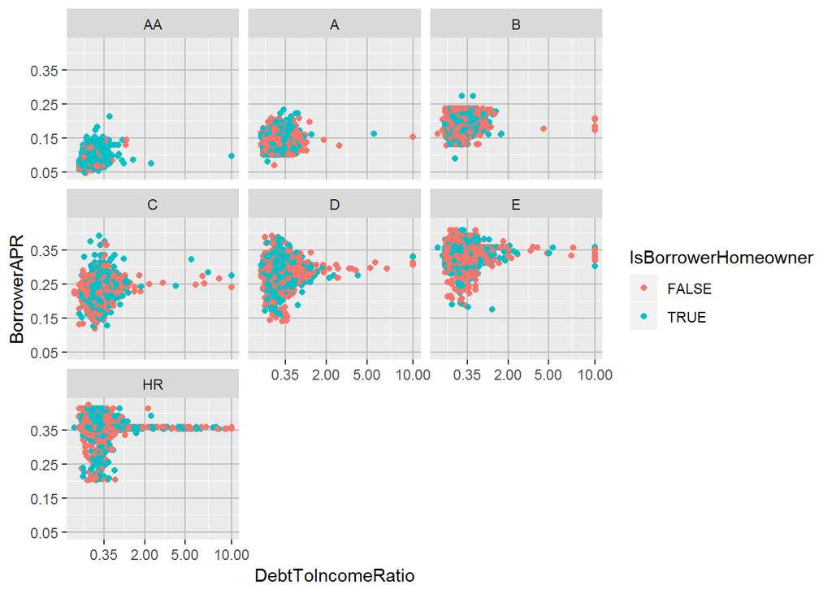

```
## ProsperRating.alpha: AA
##    Min. 1st Qu.  Median    Mean 3rd Qu.    Max.    NA's
##   0.010   0.110   0.160   0.173   0.220  10.010     216
## --------------------------------------------------------
## ProsperRating.alpha: A
##    Min. 1st Qu.  Median    Mean 3rd Qu.    Max.    NA's
##  0.0100  0.1400  0.2000  0.2162  0.2700 10.0100     835
## --------------------------------------------------------
## ProsperRating.alpha: B
##    Min. 1st Qu.  Median    Mean 3rd Qu.    Max.    NA's
##  0.0000  0.1500  0.2200  0.2369  0.3000 10.0100     924
## --------------------------------------------------------
## ProsperRating.alpha: C
##    Min. 1st Qu.  Median    Mean 3rd Qu.    Max.    NA's
##  0.0000  0.1700  0.2500  0.2727  0.3500 10.0100    1425
## --------------------------------------------------------
## ProsperRating.alpha: D
##    Min. 1st Qu.  Median    Mean 3rd Qu.    Max.    NA's
##  0.0100  0.1600  0.2400  0.2696  0.3400 10.0100    1446
## --------------------------------------------------------
## ProsperRating.alpha: E
##    Min. 1st Qu.  Median    Mean 3rd Qu.    Max.    NA's
##  0.0000  0.1600  0.2400  0.2906  0.3600 10.0100    1173
## --------------------------------------------------------
## ProsperRating.alpha: HR
##    Min. 1st Qu.  Median    Mean 3rd Qu.    Max.    NA's
##  0.0000  0.1700  0.2700  0.3782  0.4000 10.0100    1195
```

```
##
## Debt to Income Ratio Dispersion, measured by standard deviation:
```

```
## ProsperRating.alpha: AA
## [1] 0.1685822
## --------------------------------------------------------
## ProsperRating.alpha: A
## [1] 0.1426554
## --------------------------------------------------------
## ProsperRating.alpha: B
## [1] 0.2322684
## --------------------------------------------------------
## ProsperRating.alpha: C
## [1] 0.2274211
## --------------------------------------------------------
## ProsperRating.alpha: D
## [1] 0.2736307
## --------------------------------------------------------
## ProsperRating.alpha: E
## [1] 0.4203626
## --------------------------------------------------------
## ProsperRating.alpha: HR
## [1] 0.7430951
```

> Borrower revolving credit balance vs. APR faceted by Prosper rating, colored by employment status - the only thing that really seems to stand out here is the distribution in the HR category is quite a bit different from the other. There amount of borrowers with a status of “Employed” is quite a bit lower in this group, though the dominant group is still “Full-time.”:

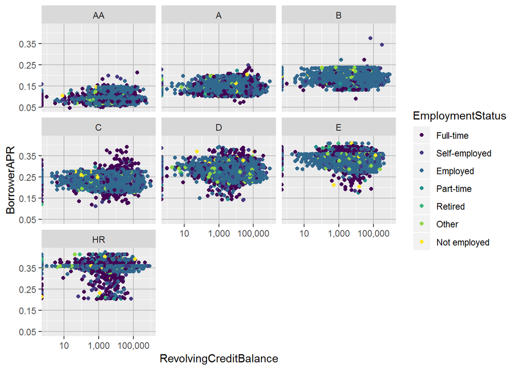

```
## ProsperRating.alpha: AA
##    Min. 1st Qu.  Median    Mean 3rd Qu.    Max.
##       0    3673    9708   18697   21899  558969
## --------------------------------------------------------
## ProsperRating.alpha: A
##    Min. 1st Qu.  Median    Mean 3rd Qu.    Max.
##       0    4653   11006   20320   23507  879891
## --------------------------------------------------------
## ProsperRating.alpha: B
##    Min. 1st Qu.  Median    Mean 3rd Qu.    Max.
##       0    4826   10820   20077   22857  877847
## --------------------------------------------------------
## ProsperRating.alpha: C
##    Min. 1st Qu.  Median    Mean 3rd Qu.    Max.
##       0    4771   10234   18925   21574  999165
## --------------------------------------------------------
## ProsperRating.alpha: D
##    Min. 1st Qu.  Median    Mean 3rd Qu.    Max.
##       0    2937    7753   15414   17011  878859
## --------------------------------------------------------
## ProsperRating.alpha: E
##    Min. 1st Qu.  Median    Mean 3rd Qu.    Max.
##       0    2851    7158   14287   15965  401603
## --------------------------------------------------------
## ProsperRating.alpha: HR
##    Min. 1st Qu.  Median    Mean 3rd Qu.    Max.
##       0    1594    6216   15337   16154  879785
```

# Multivariate Analysis

> Originally it appeared that most of the loans were more high risk. However, upon further investigation this isn’t the case. Borrowers with a high Propser ranking receive a reasonable APR. We also see that longer term and larger loan amounts are typically reserved for higher rated borrowers. One surprise is that borrower credit score is not strongly correlated with their rating. While there is clearly a relationship, there are obviously many other factors at play in building the borrowers rating. Income appears to play a small role in the rating. However, debt to income ratio and revolving credit debt don’t appear to have much influence in the rating. Perhaps this may be because they’re already factored in to the borrower’s credit score. Not being a home owner seems to be correlated with lower scores.

# Final Plots and Summary

### Plot One

| Rating | Range |
| --- | --- |
| Excellent | 750 + |
| Good | 700 - 749 |
| Fair | 650 - 699 |
| Poor | 550 - 649 |
| Bad | 549 - |

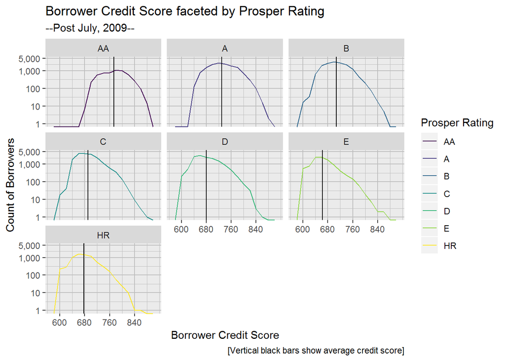

### About Plot One

When lending or borrowing from Prosper, borrower rating plays a large part in determing the loan APR. As shown here, while there is some correlation between rating and credit score, many other factors are considered.

### Plot Two

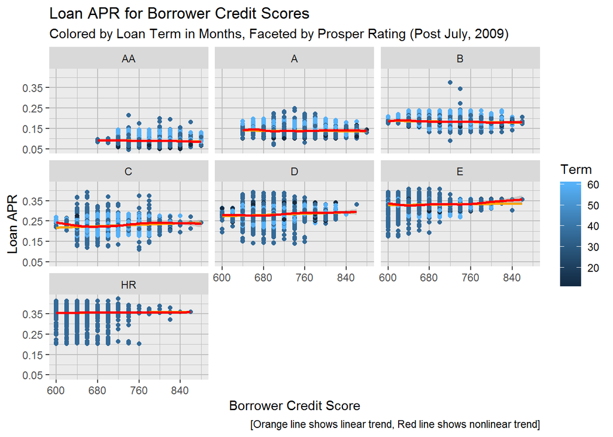

### About Plot Two

Here we see loan rates versus borrower credit scores. Each subplot groups by Prosper rating with the point color showing the loan term length. Trend lines show the clear correlation between rating and APR.

### Plot Three

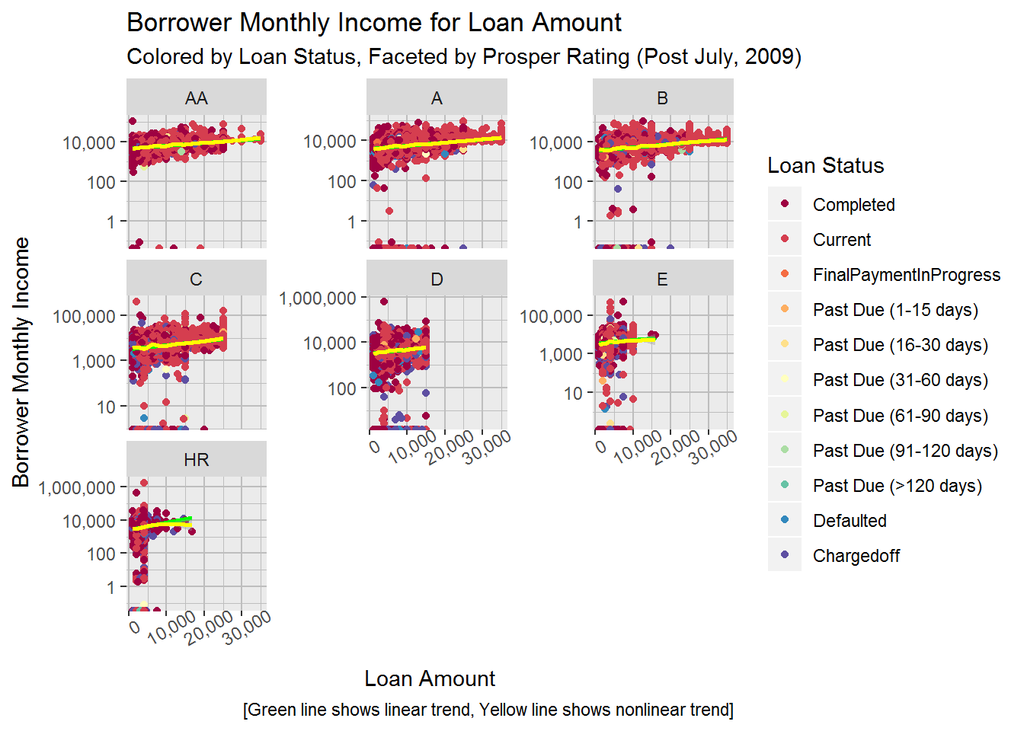

### About Plot Three

Here we borrower monthly income versus loan amount. Each subplot groups by Prosper rating with the point color showing the loan status. Trend lines show the average income for the loan. The average income for groups AA - B is similar. We see average income fall off a little for C - E, but the big trend here is a huge increase in dispersion. The HR group has slightly lower average income than the first row but the greatest income dispersion by far. We can also clearly see that as the rating decreases, the loan amount follows suit.

# Reflection

This data set contains 81 features! While this is a fantastic amount of data to explore, at first it was a big overwhelming. I spent some time learning how lenders assess credit worthiness. Based on this, I pruned the data set down to 21 features. In addition, when first looking at the data set, I found some issues. First of all, there are five different key fields. Out of those I selected one to use. Next I found that there were duplicates rows. I developed some functions to find the duplicates, determine what the discrepancies between them were, and combine them into unique rows. I also went through all the features and changed the data type to the best match. I think this was a great exercise as this is something I can leverage for future data sets. To help explore correlated features, I also wrote a function which looks at correlation values and only returns the ones with at least a weak correlation. This saves a lot of time and is important when dealing with dozens of features. Using a scatterplot matrix probably only makes sense for small data sets - say ten or fewer features.

When examining Prosper’s rating system, there’s evidence that the company learned over time. While the original credit grade closely maps to credit scores, the revised rating system is only marginally correlated with them. Using all of their data, Prosper refined their rating system. I explored what was correlated with loan APRs and Prosper ratings. While I identified some of the factors, there are clearly more at play. It would be interesting to explore additional features from the original data set and see what other correlations are present. It would also be interesting to bring some more advanced techniques to bear to groups various features and see how they predict things like loan repayment or default.